# DRC - Analysis

Thomas Lassourd

Date created: 2019-08-23

### Purpose

Cleaning and analyzing EITI data for the Democratic Republic of Congo.

We source EITI data from www.resourcedata.org, which itselfs aggregates EITI summary data in open data format shared by the international EITI secretariat here: https://eiti.org/explore-data-portal

#### Warning: this webpage is a work in progress, shared for limited consultations only. Please keep in mind that the data may require additional cleaning. There could be errors in the EITI summary data, if not in the EITI reports themselves.The formatting of the plots is also tentative and will be refined at a later stage.

#### We welcome all comments on the data sourced, the cleaning process, and preliminary plot analysis. Please email Thomas Lassourd tlassourd@resourcegovernance.org or Jean Pierre Okenda jpokenda@resourcegovernance.org.

```r
pacman::p_load(tidyverse, ggthemes, nrgiR , scales)

## get the EITI data from resource data (only downloads once a session)
if (!exists("eiti_company")) {
  eiti_company <- read_csv("https://www.resourcedata.org/dataset/7dd3c8b6-9256-4e34-9360-1519efd87407/resource/bba3b646-131b-47c5-9f4c-37019f896575/download/company-payments.csv")

}
```

Now that we have the data ready let’s do some clean up.

### Cleaning

We are only interested in data from DRC. Let’s narrow down the selection and clean the company names, the gfs codes, the gfs descriptions and the name of the revenue streams, using specifically made files (available upon request, or in the Github repository: https://github.com/ThomasNRGI/EITI_DRC).

The cleaning process requires some decisions and assumptions regarding project / company names and categorizations of revenue stream by gfs description. Here are some of the main choices we have made on company (project) names: * When projects are also reporting under mandatory listing disclosure rules, the project name in resourceprojects.org was chosen, if compatible. * When project names have changed, we use the most recent project name for all years in the data. * When projects have merged, we attribute the latest project name to the separate projects prior to the merger. E.g. payments from DCK and KOL, which merged and created KCC in 2008, are attributed to KCC. Payments from Kanuski are attributed to Mutanda. * We added a column “additional company name” to provide more data where relevant (majority owner, historic project names, etc.) * Anvil Mining Congo ( AMC) and MMG Kinsevere (MMG) are separate projects.

Here are some of the main choices we have made on gfs description and gfs codes: - Every revenue stream to state-owned companies was included in the category gfs code 1415E32 / gfs description: “Delivered/paid to state-owned enterprise(s)”, regardless of the type of revenue. This includes bonus (pas-de-porte), royalties, dividend payments, Loyers d’amodiation et/ou rente mensuelle, Fonds versés a la GCM pour la vente des scories, Redevance supplémentaires sur les réserves additionnelles, Avance contractuelle sur dividendes ou royalties futurs, Frais de consultance, Vente de Licence, Frais de renonciation au droit de préemption. - Other re-categorizations can be found in the “reconcile” excel sheet.

```r
## We import the reconciliation files in excel into a dataframe (made from initially extracting all unique occurences of company names and names of revenue streams, matching them to clean names and adding a sector variable (mining vs oil))
company_reconcile <- readxl::read_excel("reconcile.xlsx", sheet = "company_names") %>%
  mutate(company_name_clean = str_squish(company_name_clean)) %>%
  distinct()

rev_code_reconcile <- readxl::read_excel("reconcile.xlsx", sheet = "rev_codes") %>%
  mutate(gfs_code_clean = str_squish(gfs_code_clean) ,
         gfs_description_clean = str_squish(gfs_description_clean) ,
         name_of_revenue_stream_clean = str_squish(name_of_revenue_stream_clean) ) %>%
  distinct()

## We filter eiti summary data for DRC specifically, we add the clean columns for the company names, the gfs codes, the gfs descriptions and the name of the revenue streams and then delete the original variables.
drc_eiti <- eiti_company %>%
  filter(country == "Democratic Republic of Congo") %>%
  left_join(., rev_code_reconcile, by = "name_of_revenue_stream") %>%
  left_join(., company_reconcile, by = "company_name") %>%
     mutate(company_name = company_name_clean,
            gfs_code = gfs_code_clean,
            gfs_description = gfs_description_clean,
            name_of_revenue_stream = name_of_revenue_stream_clean) %>%
  select ( -c( company_name_clean , gfs_code_clean, gfs_description_clean ,  name_of_revenue_stream_clean))
```

### Create functions for sorting observations

#### Designing the functions

In the code below we create a function that takes the tibble, the grouping variable and a threshold as its arguments. This automates the same logic that we will be repeating across different charts.

```r
get_plot_data <- function(df, g_var, threshold) {
  df %>%
    filter(sector == "Mining") %>%
    group_by({{g_var}}) %>%
    summarise(total_pay = sum(value_reported_as_USD, na.rm = T)) %>%
    ungroup() %>%
    mutate(x_var = if_else(total_pay > threshold, {{g_var}}, "Other")) %>%
    group_by(x_var) %>%
    summarise(total_pay = sum(total_pay, na.rm = T)) %>%
    ungroup()
}

get_plot_data_2 <- function(df, g_var, h_var, threshold) {
  df %>%
    filter(sector == "Mining") %>%
    group_by({{g_var}}) %>%
    summarise(total_pay = sum(value_reported_as_USD, na.rm = T)) %>%
    ungroup() %>%
    mutate(x_var = if_else(total_pay > threshold, {{g_var}}, "Other")) %>%
    group_by(x_var , h_var) %>%
    summarise(total_pay = sum(total_pay, na.rm = T)) %>%
    ungroup()
}
```

#### Customized pie chart

Create a blank theme :

```r
blank_theme <- theme_minimal()+
  theme(
  axis.title.x = element_blank(),
  axis.title.y = element_blank(),
  panel.border = element_blank(),
  panel.grid=element_blank(),
  axis.ticks = element_blank(),
  plot.title=element_text(size=14, face="bold")
  )
```

### Analysis

The data is ready for some simple descriptive analysis.

The first chart shows us the total amount of payment by year.

Comment: large drop in mining revenue in 2016. Does it conform to EITI reports and other data points?

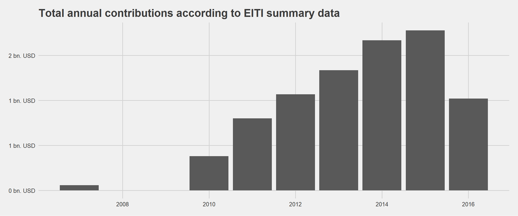

```r
drc_eiti %>%
  filter(sector == "Mining") %>%
  group_by(year) %>%
  summarise(total_pay = sum(value_reported_as_USD, na.rm = T)) %>%
  ungroup() %>%
    ggplot(aes(x = year, y = total_pay)) +
    geom_col() +
    theme_fivethirtyeight() +
    scale_y_continuous(labels = unit_format(unit = "bn. USD", scale = 1e-9, sep = " ")) +
    labs(title ="Total annual contributions according to EITI summary data", x = "year", y = "Cumulative payments")
```

The second chart shows us the mining companies that pay more than a threshold of 180 million USD over the entire period covered by the database.

Comment: the majority of payments made during that period comes from 12 companies

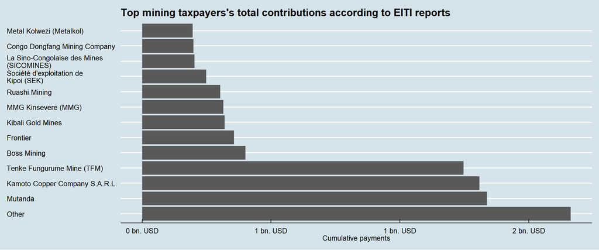

```r
get_plot_data( drc_eiti, company_name , threshold = 18e7) %>%
  ggplot(data = ., mapping = aes(x = fct_reorder(x_var, -total_pay), y = total_pay)) +
  geom_col() +
  coord_flip() +
  theme_economist() +
  scale_x_discrete(labels = function(x) str_wrap(x, width = 30)) +
  scale_y_continuous(labels = unit_format(unit = "bn. USD", scale = 1e-9, sep = " ")) +
  labs(title = "Top mining taxpayers's total contributions according to EITI reports",
       y = "Cumulative payments") +
  theme(
    axis.title.y = element_blank()
  )
```

The third chart shows us the mining companies that pay more than a threshold of 180 million USD over the entire period covered by the database.

Comment: Sicomines and SEK only make it in the top 12 because of large payments in specific years, 2012 and 2014 respectively.

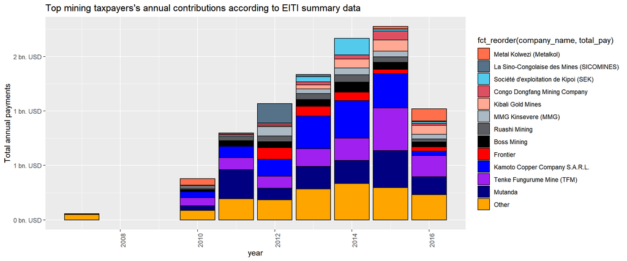

```r
drc_eiti %>%
  filter(sector == "Mining") %>%
  group_by(company_name) %>%
  mutate(total_pay = sum(value_reported_as_USD, na.rm = T)) %>%
  ungroup() %>%
  mutate(company_name = if_else(total_pay > 18e7, company_name, "Other")) %>%
  group_by(company_name, year) %>%
  summarise(total_pay = sum(value_reported_as_USD, na.rm = T)) %>%
  ungroup() %>%
  ggplot(aes(x = year, y = total_pay, fill = fct_reorder(company_name, total_pay))) +
  geom_bar(stat = "identity" , colour="black") +
  scale_fill_manual(values = c(nrgi_colors(),"black", "red", "blue", "purple" , "navy" , "orange"), na.value = nrgi_colors()[5]) +
  theme(axis.text.x = element_text(angle = 90)) +
  scale_y_continuous(labels = unit_format(unit = "bn. USD", scale = 1e-9, sep = " ")) +
  labs(title ="Top mining taxpayers's annual contributions according to EITI summary data", x = "year", y = "Total annual payments") +
  theme(
  )
```

The fourth chart shows us the major payment types, by gfs description, that contributed more than 120 million USD over the entire period covered by the database.

Note: royalties are royalties to the State (“redevance”). Royalties to SOEs are categorized within “paid to state-owned enterprises”.

Comments:

1. Surprisingly custom payments come out first, while one would expect it to be lower, based on cash flow models.
2. Payments to SOEs is the third largest payment.

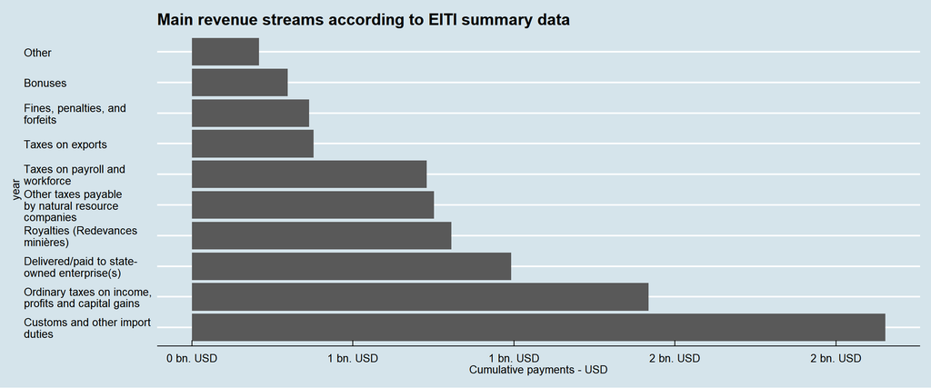

```r
get_plot_data( drc_eiti, gfs_description , threshold = 12e7) %>%
  ggplot(aes(x = fct_reorder(x_var, -total_pay), y = total_pay)) +
  geom_col() +
  coord_flip() +
  theme_economist() +
  scale_x_discrete(labels = function(x) str_wrap(x, width = 25)) +
  scale_y_continuous(labels = unit_format(unit = "bn. USD", scale = 1e-9, sep = " ")) +
  labs(title ="Main revenue streams according to EITI summary data", x = "year", y = "Cumulative payments - USD")
```

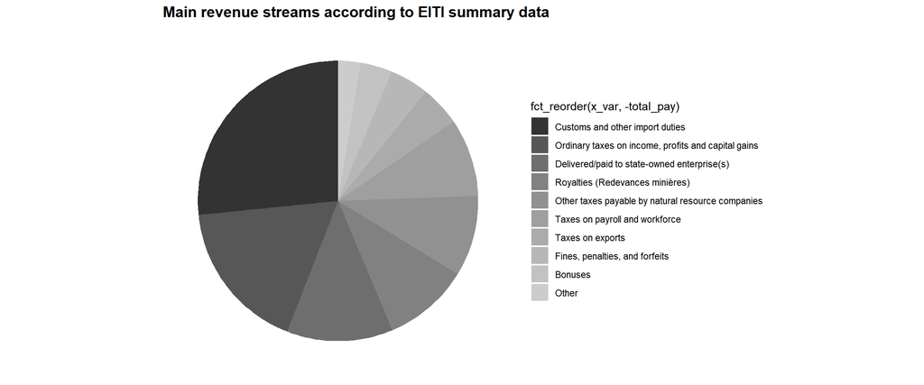

```r
get_plot_data( drc_eiti, gfs_description , threshold = 12e7) %>%
  ggplot(aes(x = " ", y = total_pay, fill = fct_reorder(x_var, -total_pay))) +
  geom_bar(width = 1, stat = "identity") +
  coord_polar("y", start=0) +
  scale_fill_grey() +
  blank_theme +
  theme(axis.text.x=element_blank()) +
    labs(title ="Main revenue streams according to EITI summary data", x = "year", y = "Cumulative payments - USD")
```

The fifth chart shows us the major payment types, by gfs description, that contributed more than 120 million USD over the entire period covered by the database, on an annual basis.

Comments:

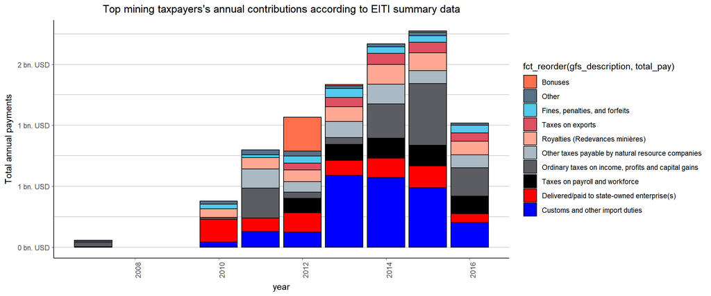

```r
drc_eiti %>%
  filter(sector == "Mining") %>%
  group_by(gfs_description) %>%
  mutate(total_pay = sum(value_reported_as_USD, na.rm = T)) %>%
  ungroup() %>%
  mutate(gfs_description = if_else(total_pay > 12e7, gfs_description, "Other")) %>%
  group_by(gfs_description, year) %>%
  summarise(total_pay = sum(value_reported_as_USD, na.rm = T)) %>%
  ungroup() %>%
  ggplot(aes(x = year, y = total_pay, fill = fct_reorder(gfs_description, total_pay))) +
  geom_bar(stat = "identity" , colour="black") +
  scale_fill_manual(values = c(nrgi_colors(),"black", "red", "blue", "purple" , "navy" , "orange"), na.value = nrgi_colors()[5]) +
  nrgi_theme() +
  theme(axis.text.x = element_text(angle = 90)) +
  scale_y_continuous(labels = unit_format(unit = "bn. USD", scale = 1e-9, sep = " ")) +
  labs(title = str_wrap("Top mining taxpayers's annual contributions according to EITI summary data"), x = "year", y = str_wrap("Total annual payments"))
```

The sixth chart shows us the major gfs description of the payments of the mining companies that pay more than a threshold of 180 million USD over the entire period covered by the database.

Comments:

1. MUMI, KCC, TFM and Kibali pay a lot of custom duties: investigate
2. KCC, Metalkol, TFM, Ruahsi, Boss, and MUMI pay significant amount to SOEs.
3. Very large bonus payments from Sicomines and Frontier.
4. Very little royalties paid by Metalkol and Sicomines.

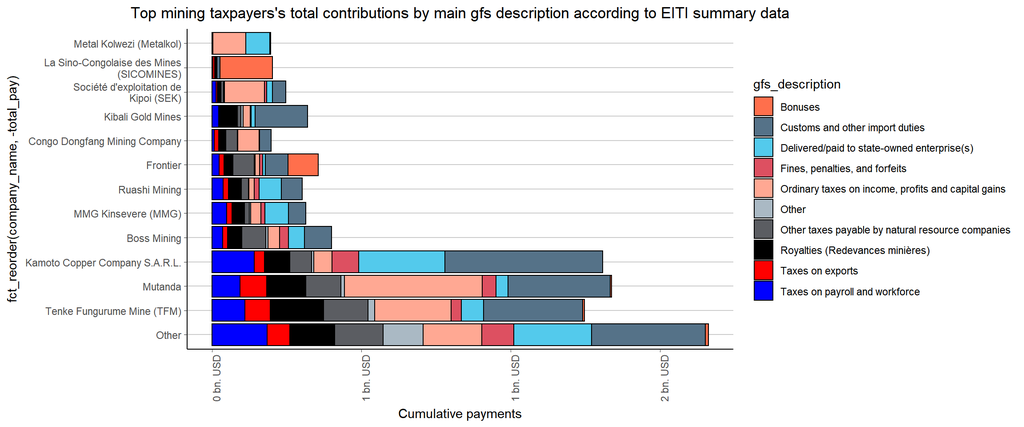

```r
drc_eiti %>%
  filter(sector == "Mining") %>%
  group_by(company_name) %>%
  mutate(total_pay = sum(value_reported_as_USD, na.rm = T)) %>%
  ungroup() %>%
  mutate(company_name = if_else(total_pay > 18e7, company_name, "Other")) %>%
  group_by(gfs_description) %>%
  mutate(total_pay = sum(value_reported_as_USD, na.rm = T)) %>%
  ungroup() %>%
  mutate(gfs_description = if_else(total_pay > 12e7, gfs_description, "Other")) %>%
  group_by(company_name, gfs_description) %>%
  summarise(total_pay = sum(value_reported_as_USD, na.rm = T)) %>%
  ungroup() %>%
  ggplot(aes(x = fct_reorder(company_name, -total_pay), y = total_pay, fill = gfs_description)) +
  geom_bar(stat = "identity" , colour="black") +
  scale_fill_manual(values = c(nrgi_colors(),"black", "red", "blue", "purple" , "navy" , "orange"), na.value = nrgi_colors()[5]) +
  nrgi_theme() +
  theme(axis.text.x = element_text(angle = 90)) +
  coord_flip() +
  scale_x_discrete(labels = function(x) str_wrap(x, width = 30)) +
  scale_y_continuous(labels = unit_format(unit = "bn. USD", scale = 1e-9, sep = " ")) +
  labs(title ="Top mining taxpayers's total contributions by main gfs description according to EITI summary data", y = "Cumulative payments")
```

Comments:

1. Confirms that KCC, MUMI, TFM and Kibali have paid very large sums in custom duties. Need to look into it. Possible explanations: fuel imports and other inputs?

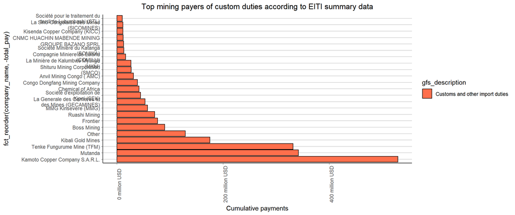

```r
drc_eiti %>%
  filter(sector == "Mining" ,
         gfs_description == "Customs and other import duties"
         ) %>%
  group_by(company_name) %>%
  mutate(total_pay = sum(value_reported_as_USD, na.rm = T)) %>%
  ungroup() %>%
  mutate(company_name = if_else(total_pay > 1e7, company_name, "Other")) %>%
  group_by(company_name, gfs_description) %>%
  summarise(total_pay = sum(value_reported_as_USD, na.rm = T)) %>%
  ungroup() %>%
    ggplot(aes(x = fct_reorder(company_name, -total_pay), y = total_pay, fill = gfs_description)) +
  geom_bar(stat = "identity" , colour="black") +
  scale_fill_manual(values = c(nrgi_colors(),"black", "red", "blue", "purple" , "navy" , "orange"), na.value = nrgi_colors()[5]) +
  nrgi_theme() +
  theme(axis.text.x = element_text(angle = 90)) +
  coord_flip() +
  scale_x_discrete(labels = function(x) str_wrap(x, width = 30)) +
  scale_y_continuous(labels = unit_format(unit = "million USD", scale = 1e-6, sep = " ")) +
  labs(title ="Top mining payers of custom duties according to EITI summary data", y = "Cumulative payments")
```

The eigth and ninth charts show us the details of the SOE payments by company and by year.

Comments:

1. Royalties are the first reveue flow to SOEs, followed by Pas de Porte (bonuses)
2. KCC is by far the largest payer to SOEs
3. PAs de porte were the highest between 2010 and 2012
4. Frais de consultance only show up from TFM and MUMI. But are very regular payments between 2013 and 2016.
5. Fonds pour la vente des scories (payments to GCM for deposit sales) only show up from STL and Rubamin. But are significant payment from 2013 to 2016.
6. SOEs receive annually between 60 and 180 million USD in total payments from mining companies.

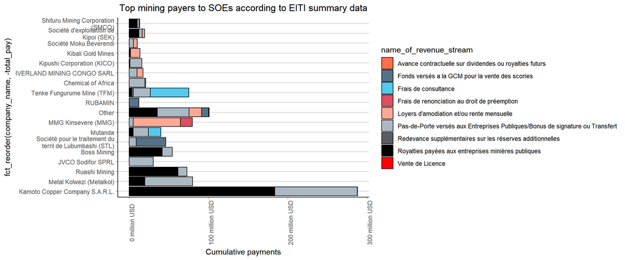

```r
drc_eiti %>%
  filter(sector == "Mining" ,
         gfs_description == "Delivered/paid to state-owned enterprise(s)"
         ) %>%
  group_by(company_name) %>%
  mutate(total_pay = sum(value_reported_as_USD, na.rm = T)) %>%
  ungroup() %>%
  mutate(company_name = if_else(total_pay > 1e7, company_name, "Other")) %>%
  group_by(company_name, name_of_revenue_stream) %>%
  summarise(total_pay = sum(value_reported_as_USD, na.rm = T)) %>%
  ungroup() %>%
    ggplot(aes(x = fct_reorder(company_name, -total_pay), y = total_pay, fill = name_of_revenue_stream)) +
  geom_bar(stat = "identity" , colour="black") +
  scale_fill_manual(values = c(nrgi_colors(),"black", "red", "blue", "purple" , "navy" , "orange"), na.value = nrgi_colors()[5]) +
  nrgi_theme() +
  theme(axis.text.x = element_text(angle = 90)) +
  coord_flip() +
  scale_x_discrete(labels = function(x) str_wrap(x, width = 30)) +
  scale_y_continuous(labels = unit_format(unit = "million USD", scale = 1e-6, sep = " ")) +
  labs(title ="Top mining payers to SOEs according to EITI summary data", y = "Cumulative payments")
```

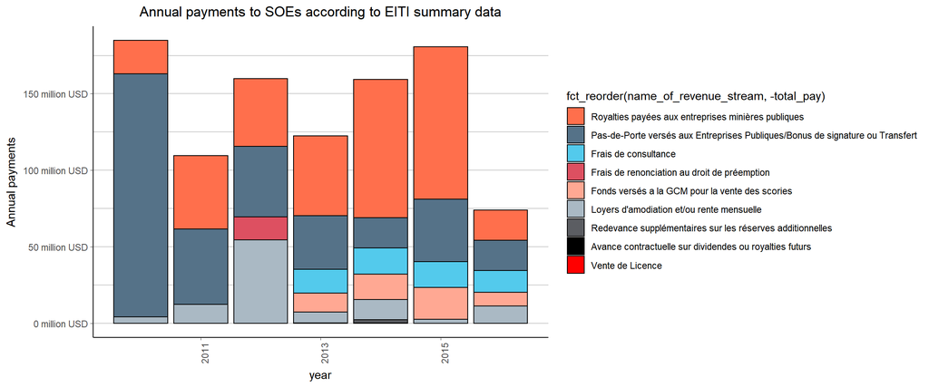

```r
drc_eiti %>%
  filter(sector == "Mining" ,
         gfs_description == "Delivered/paid to state-owned enterprise(s)"
         ) %>%
  group_by(year, name_of_revenue_stream) %>%
  summarise(total_pay = sum(value_reported_as_USD, na.rm = T)) %>%
  ungroup() %>%
    ggplot(aes(x = year , y = total_pay , fill = fct_reorder(name_of_revenue_stream, -total_pay))) +
  geom_bar(stat = "identity" , colour="black") +
  scale_fill_manual(values = c(nrgi_colors(),"black", "red", "blue", "purple" , "navy" , "orange"), na.value = nrgi_colors()[5]) +
  nrgi_theme() +
  theme(axis.text.x = element_text(angle = 90)) +
  scale_y_continuous(labels = unit_format(unit = "million USD", scale = 1e-6, sep = " ")) +
  labs(title ="Annual payments to SOEs according to EITI summary data", y = "Annual payments")
```

The tenth chart in facet wrap shows us the major gfs description of the payments of the mining companies that pay more than a threshold of 180 million USD each year covered by the database.

Comments:

1. KCC’s payments almost stop in 2016
2. Comapnies that have a “normal” payment profile over time: Boss, MMG, Ruashi, Kibali, Frontier.
3. TFM: exceptionnally large income tax payment in 2015
4. Kipoi: exceptionnally large income tax payment in 2014
5. MUMI: exceptionnally large income tax payment in 2011 and 2015
6. Meltalkol: exceptionnally large income tax payment in 2016

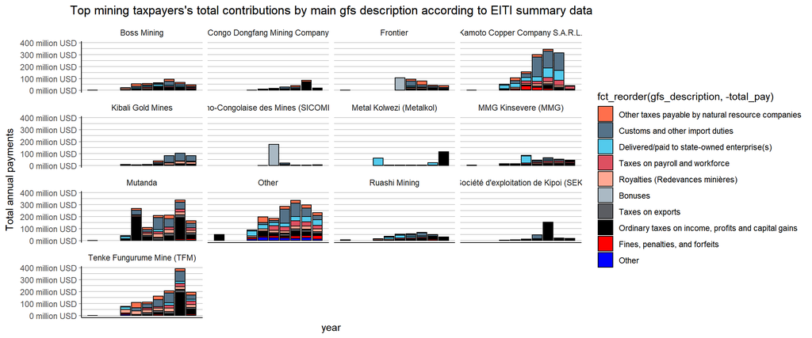

```r
drc_eiti %>%
  filter(sector == "Mining") %>%
  group_by(company_name) %>%
  mutate(total_pay = sum(value_reported_as_USD, na.rm = T)) %>%
  ungroup() %>%
  mutate(company_name = if_else(total_pay > 18e7, company_name, "Other")) %>%
  group_by(gfs_description) %>%
  mutate(total_pay = sum(value_reported_as_USD, na.rm = T)) %>%
  ungroup() %>%
  mutate(gfs_description = if_else(total_pay > 12e7, gfs_description, "Other")) %>%
  group_by(company_name, gfs_description , year) %>%
  summarise(total_pay = sum(value_reported_as_USD, na.rm = T)) %>%
  ungroup() %>%
  ggplot(aes(x = year, y = total_pay, fill = fct_reorder(gfs_description, -total_pay))) +
  geom_bar(stat = "identity" , colour="black") +
  scale_fill_manual(values = c(nrgi_colors(),"black", "red", "blue", "purple" , "navy" , "orange"), na.value = nrgi_colors()[5]) +
  nrgi_theme() +
  theme(axis.text.x = element_text(angle = 90)) +
  scale_x_discrete(labels = function(x) str_wrap(x, width = 30)) +
  scale_y_continuous(labels = unit_format(unit = "million USD", scale = 1e-6, sep = " ")) +
  facet_wrap(~str_wrap(company_name)) +
  labs(title ="Top mining taxpayers's total contributions by main gfs description according to EITI summary data", y = "Total annual payments")
```

The eleventh chart in facet wrap shows us how much payments are made in each gfs category each year by the mining companies that pay more than a threshold of 180 million USD each year covered by the database.

Comments:

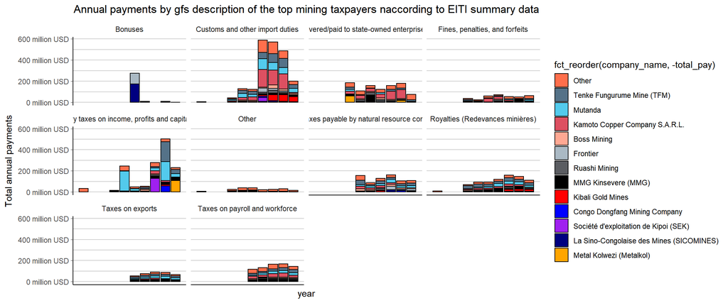

```r
drc_eiti %>%
  filter(sector == "Mining") %>%
  group_by(company_name) %>%
  mutate(total_pay = sum(value_reported_as_USD, na.rm = T)) %>%
  ungroup() %>%
  mutate(company_name = if_else(total_pay > 18e7, company_name, "Other")) %>%
  group_by(gfs_description) %>%
  mutate(total_pay = sum(value_reported_as_USD, na.rm = T)) %>%
  ungroup() %>%
  mutate(gfs_description = if_else(total_pay > 12e7, gfs_description, "Other")) %>%
  group_by(company_name, gfs_description , year) %>%
  summarise(total_pay = sum(value_reported_as_USD, na.rm = T)) %>%
  ungroup() %>%
  ggplot(aes(x = year, y = total_pay, fill = fct_reorder(company_name, -total_pay))) +
  geom_bar(stat = "identity" , colour="black") +
  scale_fill_manual(values = c(nrgi_colors(),"black", "red", "blue", "purple" , "navy" , "orange"), na.value = nrgi_colors()[5]) +
  nrgi_theme() +
  theme(axis.text.x = element_text(angle = 90)) +
  scale_x_discrete(labels = function(x) str_wrap(x, width = 30)) +
  scale_y_continuous(labels = unit_format(unit = "million USD", scale = 1e-6, sep = " ")) +
  facet_wrap(~gfs_description) +
  labs(title ="Annual payments by gfs description of the top mining taxpayers naccording to EITI summary data", y = "Total annual payments")
```

### Next steps

We will look at payments to different government agencies - especially for SOE payments. This requires to look at the EITI summary data from the perspective of collecting agencies.